# OncoSimulR: forward genetic simulation in asexual populations with arbitrary epistatic interactions and a focus on modeling tumor progression.

## 9.2 Random fitness landscapes from Kauffman’s NK model

You can also use Kauffman’s NK model (e.g., Ferretti et al. 2016; Brouillet et al. 2015). We call the function `fl_generate` from MAGELLAN (Brouillet et al. 2015).

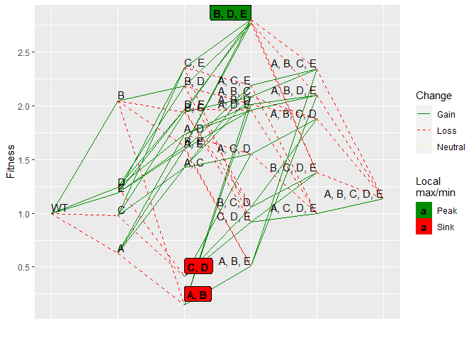

```r
rnk <- rfitness(5, K = 3, model = "NK")
plot(rnk)
```

```r
oncoSimulIndiv(allFitnessEffects(genotFitness = rnk))
##
## Individual OncoSimul trajectory with call:
##  oncoSimulIndiv(fp = allFitnessEffects(genotFitness = rnk))
##
##   NumClones TotalPopSize LargestClone MaxNumDrivers MaxDriversLast
## 1         6    200059218    200051383             0              0
##   NumDriversLargestPop TotalPresentDrivers FinalTime NumIter
## 1                    0                   0  137.7012    1713
##   HittedWallTime HittedMaxTries errorMF minDMratio minBMratio
## 1          FALSE          FALSE      NA   122087.1      2e+05
##   OccurringDrivers
## 1
##
## Final population composition:
##   Genotype         N
## 1                929
## 2     A, B       210
## 3        B 200051383
## 4     B, C      1570
## 5     B, D      4355
## 6     B, E       771
```

## 9.3 Random fitness landscapes from an additive model

This model evaluates fitness with different contributions of each allele, which will be randomly generated.

Given a number a genes by the user, the code uses rnorm to generate random contribution for the mutated allele in each locus. Later, this constributions will be used in the generation of the matrix that gives the value of fitness for each combination of wild type/mutated alleles by addition of the values for each locus and combination.

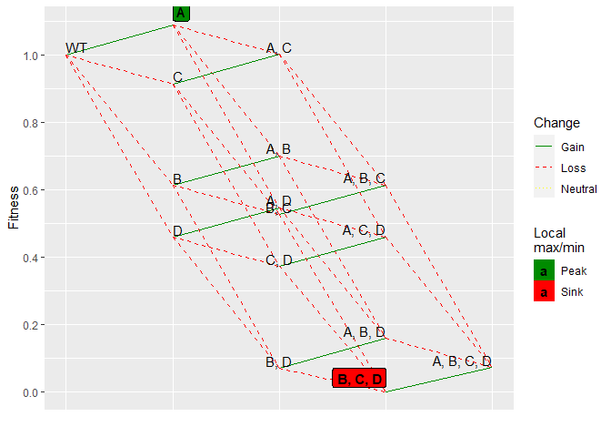

```r
radd <- rfitness(4, model = "Additive", mu = 0, sd = 0.5)
plot(radd)
```

## 9.4 Random fitness landscapes from Eggbox model

You can also use Eggbox model (e.g., Ferretti et al. 2016; Brouillet et al. 2015), where each locus is either high or low fitness (depending on the “e” parameter value), with a systematic change between each neighbor. We call the function `fl_generate` from MAGELLAN (Brouillet et al. 2015) to generate these landscapes.

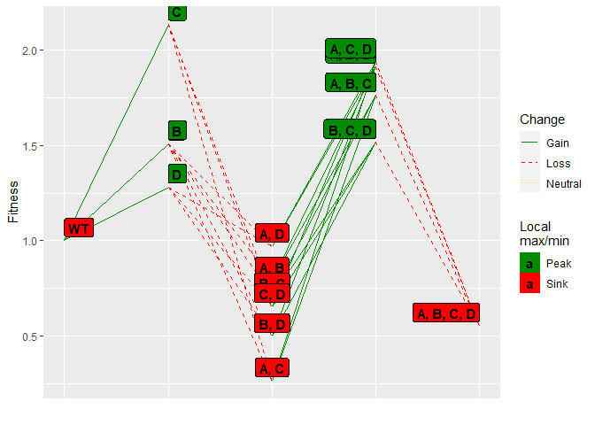

```r
regg <- rfitness(4, model = "Eggbox", e = 1, E = 0.5)
plot(regg)
```

## 9.5 Random fitness landscapes from Ising model

In the Ising model (e.g., Ferretti et al. 2016; Brouillet et al. 2015), loci are arranged sequentially and each locus interacts with its physical neighbors. For each pair of interacting loci, there is a cost to (log)fitness if both alleles are not identical (and therefore ‘compatible’); in this case, the cost for incompatibility `i` is applied. The last and the first loci will interact only if ‘circular’ is set. The implementation of this model is decribedin (Brouillet et al. 2015), and we use a call to MAGELLAN code to generate the landscape.

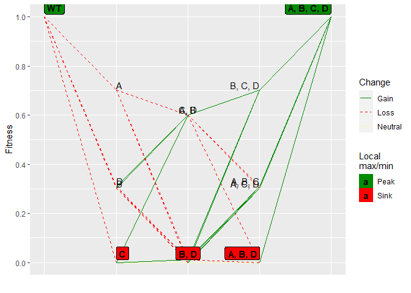

```r
ris <- rfitness(g = 4, model = "Ising", i = 0.002, I = 0.45)
plot(ris)
```

## 9.6 Random fitness landscapes from Full models

MAGELLAN also offers the possibility to combine different models with their own parameters in order to generate a Full model. The models combined are:

- House of cards: `H` is the number of interacting genes.
- Multiplicative (what we call additive): `s` and `S` mean and SD for generating random fitnesses. `d` is a diminishing (negative) or increasing (positive) return as you approach the peak.
- Kauffman NK: each locus interacts with any other `K` loci that can be chosen randomly pasing “r = TRUE” or among its neigbors.
- RMF: explained at 9.1.
- Ising: `i` and `I` mean and SD for incompatibility. If `circular` option is provided, the last and first alleles can interact (circular arrangement).
- Eggbox: In this model, each locus is considered as high or low fitness. From one locus to another the fitness changes its sign so that one is benefficial and its neigbor is detrimental. `e` and `E` are fitness and noise for fitness.
- Optimum: there is an optimum fitness contribution defined by `o` $mu$ and `O` $sigma$ and every locus has a production `p`and `P` (also mean and sd respectively).

All models can be taken into account for the fitness calculation. With default parameters, neither of Ising, Eggbox or Optimum contribute to fitness lanadcape generation as all `i`, `e`, `o` and `p` all `== 0`. Also, as all parameters refering to standard deviations have value `== -1`, those are also have no effect unless changed. Further details can be found in MAGELLAN’s webpage http://wwwabi.snv.jussieu.fr/public/Magellan/ and (Brouillet et al. 2015).

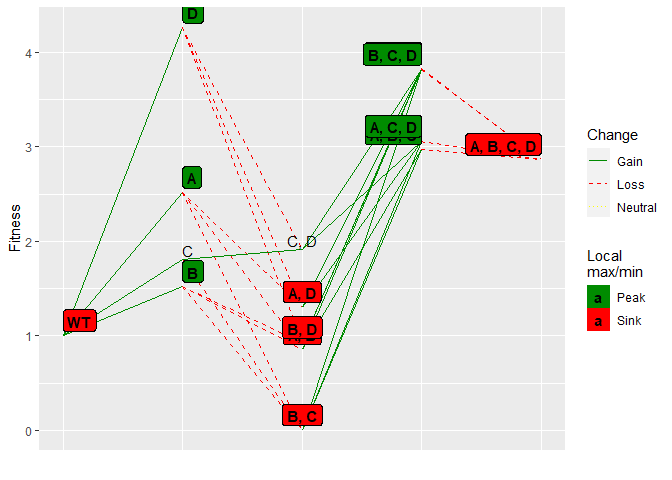

```r
rnk <- rfitness(4, model = "Full", i = 0.5, I = 0.1,
                e = 2, s = 0.3, S = 0.08)
plot(rnk)
```

## 9.7 Epistasis and fitness landscape statistics

We can call MAGELLAN’s (Brouillet et al. 2015) `fl_statistics` to obtain fitness landscape statistics, including measures of sign and reciprocal sign epistasis. See the help of `Magellan_stats` for further details on output format. For example:

```r
rnk1 <- rfitness(6, K = 1, model = "NK")
Magellan_stats(rnk1)
##      ngeno     npeaks     nsinks      gamma     gamma.        r.s
##     64.000      2.000      3.000      0.769      0.738      1.005
##    nchains     nsteps       nori      depth       magn       sign
##      2.000      8.000      6.000      2.000      0.508      0.117
##      rsign       f.1.       X.2.      f.3..     mode_f     outD_m
##      0.067      0.688      0.290      0.023      1.000      3.785
##     outD_v    steps_m    reach_m     fitG_m      opt_i mProbOpt_0
##      2.063      2.727      9.290     32.484      2.000      0.384
##    opt_i.1 mProbOpt_1
##     11.000      0.616

rnk2 <- rfitness(6, K = 4, model = "NK")
Magellan_stats(rnk2)
##      ngeno     npeaks     nsinks      gamma     gamma.        r.s
##     64.000      6.000      9.000      0.214      0.063      3.723
##    nchains     nsteps       nori      depth       magn       sign
##      5.000     10.000      7.000      3.000      0.258      0.338
##      rsign       f.1.       X.2.      f.3..     mode_f     outD_m
##      0.237      0.117      0.344      0.539      3.000      1.812
##     outD_v    steps_m    reach_m     fitG_m      opt_i mProbOpt_0
##      3.619      2.017      6.897     34.086      1.000      0.405
##    opt_i.1 mProbOpt_1    opt_i.2 mProbOpt_2    opt_i.3 mProbOpt_3
##     18.000      0.055     23.000      0.104     27.000      0.065
##    opt_i.4 mProbOpt_4    opt_i.5 mProbOpt_5
##     38.000      0.210     60.000      0.161
```

# 10 Frequency-dependent fitness

(*Note that except for the example of 10.2, based on Hurlbut et al. (2018), the examples below are not used because of their biological realism, but rather to show some key features of the software*)

With frequency-dependence fitness we can make fitness (actually, birth rate) depend on the frequency of other genotypes. We specify how the fitness (birth rate) of each genotype depends (or not) on other genotypes. Thus, this is similar to the explicit mapping of genotypes to fitness (see 3.1.1), but fitness can be a function of the abundance (relative or absolute) of other genotypes. Frequency-dependent fitness allows you to examine models from **game theory** and **adaptive dynamics**. Game theory has long tradition in evolutionary biology (Maynard Smith 1982) and has been widely used in cancer (see, for example, Tomlinson 1997; Basanta and Deutsch 2008; Archetti and Pienta 2019, for classical papers that cover from early uses to a very recent review).

Since birth rate can be an arbitrary function of the frequencies of other clones, we can model competition, cooperation and mutualism, parasitism and predation, and commensalism. (Recall that in the “Exp” model death rate is constant and fixed to 1. In the “McFL” and “McFLD” models, death rate is density-dependent —but not frequency-dependent. You can thus model all those phenomena by, for example, making the effects of clones $i$, $j$ on each other and on their own be asymmetric on their birth rates). See examples in section 10.4; as explained there, if you use the “Exp” model, you might want to decrease the value of `sampleEvery`.

The procedure for working with the frequency-dependent functionality is the general one with OncoSimulR. We first create a data frame with the mapping between genotypes and their (frequency-dependent) fitness, similar to section 3.1.1. For example, a two-column data frame, where the first column are the genotypes and the second column contains, as strings, the expressions for the function that relate fitness to frequencies of other genotypes. (We can also use a data frame with $g + 1$ columns; each of the first $g$ columns contains a 1 or a 0 indicating that the gene of that column is mutated or not. Column $g+ 1$ contains the expressions for the fitness specifications; see `oncoSimulIndiv` and `allFitnessEffects` for examples). Once this data frame is created, we pass it to `allFitnessEffects`. From there, simulation proceeds as usual.

How complex can the functions that specify fitness be? We use library [ExprTk](https://github.com/ArashPartow/exprtk) for the fitness specifications so the range of functions you can use is very large (http://www.partow.net/programming/exprtk/), including of course the usual arithmetic expressions, logical expressions (so you can model thresholds or jumps and use step functions), and a wide range of mathematical functions (so linear, non-linear, convex, concave, etc, functions can be used, including of course affine fitness functions as in Gerstung, Nakhoul, and Beerenwinkel 2011).

## 10.1 A first example with frequency-dependent fitness

The following is an arbitrary example. We will model birth rate of some genotypes as a function of the relative frequencies of other genotypes; we use `f_1` to denote the relative frequency of the genotype with the first gene mutated, `f_1_2` to denote the relative frequency of the genotype with the first and second genes mutated, etc, and `f_` to denote the frequency of the WT genotype —below, in sections 10.3, 10.5, and 10.4, we will use absolute number of cells instead of relative frequencies). (As we have discussed already, instead of `f_1` you can, and probably should for any example except trivial ones, use `f_A` or `f_genotype expressed as combination of gene names`).

```r
## Define fitness of the different genotypes
gffd <- data.frame(
    Genotype = c("WT", "A", "B", "C", "A, B"),
    Fitness = c("1 + 1.5 * f_A_B",
                "1.3 + 1.5 * f_A_B",
                "1.4",
                "1.1 + 0.7*((f_A + f_B) > 0.3) + f_A_B",
                "1.2 + sqrt(f_1 + f_C + f_B) - 0.3 * (f_A_B > 0.5)"))
```

You could also specify that as

```r
## Define fitness of the different genotypes
gffdn <- data.frame(
    Genotype = c("WT", "A", "B", "C", "A, B"),
    Fitness = c("1 + 1.5 * f_1_2",
                "1.3 + 1.5 * f_1_2",
                "1.4",
                "1.1 + 0.7*((f_1 + f_2) > 0.3) + f_1_2",
                "1.2 + sqrt(f_1 + f_3 + f_2) - 0.3 * (f_1_2 > 0.5)"),
    stringsAsFactors = FALSE)
```

but it is *strongly preferred* to use explicit gene name letters (otherwise, you must keep in mind how R orders names of genes when making the mapping from letters to numbers).

Let us verify that we have specified what we think we have specified using `evalAllGenotypes` (we have done this repeatedly in this vignette, for example in 1.3.2 or 1.6 or 5.1. Because fitness can depend on population sizes of different populations, we need to pass the populations sizes at which we want fitness evaluated in `evalAllGenotypes`.

Note that when calling `allFitnessEffects` we have to set the paramenter `frequencyDependentFitness` to TRUE. Since we are using relative frequencies, we can be explicit and specify `freqType = "rel"` (though it is not needed). We will see below (10.3, 10.5, and 10.4) several examples with absolute numbers.

When passing `spPopSizes` it is also strongly preferred to use a named vector as that allows the code to run some checks. Otherwise, the order of the population sizes *must* be identical to that in the table with the fitness descriptions (component `full_FDF_spec` in the fitness effects object).

```r
evalAllGenotypes(allFitnessEffects(genotFitness = gffd,
                         frequencyDependentFitness = TRUE,
                         frequencyType = "rel"),
                 spPopSizes = c(WT = 100, A = 20, B = 20, C = 30, "A, B" = 0))
##   Genotype  Fitness
## 1       WT 1.000000
## 2        A 1.300000
## 3        B 1.400000
## 4        C 1.100000
## 5     A, B 1.841689
## 6     A, C 0.000000
## 7     B, C 0.000000
## 8  A, B, C 0.000000

## Notice the warning
evalAllGenotypes(allFitnessEffects(genotFitness = gffd,
                         frequencyDependentFitness = TRUE,
                         frequencyType = "rel"),
                 spPopSizes = c(100, 30, 40, 0, 10))
## Warning in match_spPopSizes(spPopSizes, fmEffects): spPopSizes
## unnamed: cannot check genotype names.
##   Genotype  Fitness
## 1       WT 1.083333
## 2        A 1.383333
## 3        B 1.400000
## 4        C 1.855556
## 5     A, B 1.823610
## 6     A, C 0.000000
## 7     B, C 0.000000
## 8  A, B, C 0.000000

evalAllGenotypes(allFitnessEffects(genotFitness = gffd,
                         frequencyDependentFitness = TRUE,
                         frequencyType = "rel"),
                 spPopSizes = c(100, 30, 40, 0, 100))
## Warning in match_spPopSizes(spPopSizes, fmEffects): spPopSizes
## unnamed: cannot check genotype names.
##   Genotype  Fitness
## 1       WT 1.555556
## 2        A 1.855556
## 3        B 1.400000
## 4        C 1.470370
## 5     A, B 1.709175
## 6     A, C 0.000000
## 7     B, C 0.000000
## 8  A, B, C 0.000000
```

The numbered one gives the same results. Note as well that using `frequencyType` is not needed (the default, `auto`, infers the type)

```r
evalAllGenotypes(allFitnessEffects(genotFitness = gffdn,
                         frequencyDependentFitness = TRUE),
                 spPopSizes = c(100, 20, 20, 30, 0))
## frequencyType set to 'auto'
## Warning in match_spPopSizes(spPopSizes, fmEffects): spPopSizes
## unnamed: cannot check genotype names.
##   Genotype  Fitness
## 1       WT 1.000000
## 2        A 1.300000
## 3        B 1.400000
## 4        C 1.100000
## 5     A, B 1.841689
## 6     A, C 0.000000
## 7     B, C 0.000000
## 8  A, B, C 0.000000

evalAllGenotypes(allFitnessEffects(genotFitness = gffdn,
                         frequencyDependentFitness = TRUE),
                 spPopSizes = c(100, 30, 40, 0, 10))
## frequencyType set to 'auto'
## Warning in match_spPopSizes(spPopSizes, fmEffects): spPopSizes
## unnamed: cannot check genotype names.
##   Genotype  Fitness
## 1       WT 1.083333
## 2        A 1.383333
## 3        B 1.400000
## 4        C 1.855556
## 5     A, B 1.823610
## 6     A, C 0.000000
## 7     B, C 0.000000
## 8  A, B, C 0.000000

evalAllGenotypes(allFitnessEffects(genotFitness = gffdn,
                         frequencyDependentFitness = TRUE),
                 spPopSizes = c(100, 30, 40, 0, 100))
## frequencyType set to 'auto'
## Warning in match_spPopSizes(spPopSizes, fmEffects): spPopSizes
## unnamed: cannot check genotype names.
##   Genotype  Fitness
## 1       WT 1.555556
## 2        A 1.855556
## 3        B 1.400000
## 4        C 1.470370
## 5     A, B 1.709175
## 6     A, C 0.000000
## 7     B, C 0.000000
## 8  A, B, C 0.000000
```

The fitness specification is correct. Let us now create the `allFitnessEffects` object and simulate. We will use the McFL model, so in addition to the frequency dependence in the birth rates, there is also density dependence in the death rate (see section 3).

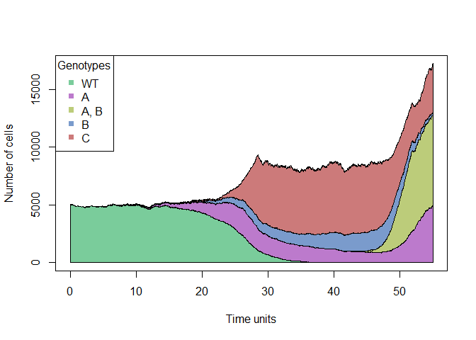

```r
afd <- allFitnessEffects(genotFitness = gffd,
                         frequencyDependentFitness = TRUE,
                         frequencyType = "rel")

set.seed(1) ## for reproducibility
sfd <- oncoSimulIndiv(afd,
                     model = "McFL",
                     onlyCancer = FALSE,
                     finalTime = 55, ## short, for speed
                     mu = 1e-4,
                     initSize = 5000,
                     keepPhylog = FALSE,
                     seed = NULL,
                     errorHitMaxTries = FALSE,
                     errorHitWallTime = FALSE)
plot(sfd, show = "genotypes")
```

There is no need to specify the fitness of all possible genotypes (and no need to always specify the fitness of a WT): those are taken to be 0. But no fitness expression can, thus, contain a function of the genotypes for which fitness is not specified (e.g., suppose you do not pass the fitness of genotype “B”: it will be taken as 0; but no genotype can have, in its fitness, a function such as “2 * f_B”).

## 10.2 Hurlbut et al., 2018: a four-cell example with angiogenesis and cytotoxicity

The following example is based on Hurlbut et al. (2018). As explained in p. 3 of that paper, “Stromal cancer cells (A-) [WT in the code below] have no particular benefit or cost unique to themselves, and they are considered a baseline neutral cell within the context of the model. In contrast, angiogenesis-factor producing cells (A+) [A in the code below] vascularize the local tumor area which consequently introduces a nutrient rich blood to the benefit of all interacting cells. Nutrient recruitment expands when A+ cells interact with one another. Cytotoxic cells (C) release a chemical compound which harms heterospecific cells and increases their rate of cell death. The cytotoxic cells benefit from the resulting disruption in competition caused by the interaction. For simplicity, our model presumes that cytotoxic cells are themselves immune to this class of agent. Finally, proliferative cells (P) possess a reproductive or metabolic advantage relative to the other cell types. In our model this advantage does not compound with the nutrient enrichment produced by vascularization when A+ cells are present; however, it does place the proliferative cell at a greater vulnerability to cytotoxins.”

They provide, in p. 4, the payoff matrix reproduced in Figure 10.1:

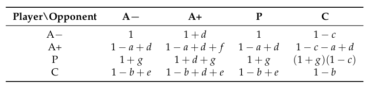

Figure 10.1: Payoff matrix from Table 2 of Hurlbut et al., 2018, ‘Game Theoretical Model of Cancer Dynamics withFour Cell Phenotypes’, *Games*, 9, 61; doi:10.3390/g9030061.

As explained in p. 6 (equation 1) of Hurlbut et al. (2018), we can write the fitness of the four types as **f**=G**u**, where **f** and **u** are the vectors with the four fitnesses and frequencies (where each element of **u** corresponds to the relative frequencies of stromal, angiogenic, proliferative, and cytotoxic cells), and G is the payoff matrix in Figure 10.1.

To allow modelling scenarios with different values for the parameters in Figure 10.1 we will define a function to create the data frame of frequency-dependent fitnesses. First, we will assume that each one of types A+, P, and C, are all derived from WT by a single mutation in one of three genes, say, A, P, C, respectively.

```r
create_fe <- function(a, b, c, d, e, f, g,
                        gt = c("WT", "A", "P", "C")) {
  data.frame(Genotype = gt,
             Fitness = c(
                 paste0("1 + ",
                       d, " * f_A ",
                       "- ", c, " * f_C"),
                 paste0("1 - ", a,
                     " + ", d, " + ",
                       f, " * f_A ",
                      "- ", c, " * f_C"),
                 paste0("1 + ", g, " + ",
                       d, " * f_A ",
                       "- ", c, " * (1 + ",
                       g, ") * f_C"),
                 paste0("1 - ", b, " + ",
                       e, " * f_ + ",
                       "(", d, " + ",
                       e, ") * f_A + ",
                       e , " * f_P")))
}
```

We can check we recover Figure 10.1:

```r
create_fe("a", "b", "c", "d", "e", "f", "g")
##   Genotype                                  Fitness
## 1       WT                    1 + d * f_A - c * f_C
## 2        A            1 - a + d + f * f_A - c * f_C
## 3        P      1 + g + d * f_A - c * (1 + g) * f_C
## 4        C 1 - b + e * f_ + (d + e) * f_A + e * f_P
```

We could model a different set of ancestor-dependent relationships:

```r
## Different assumption about origins from mutation:
## WT -> P; P -> A,P; P -> C,P

create_fe2 <- function(a, b, c, d, e, f, g,
                        gt = c("WT", "A", "P", "C", "A, P", "A, C",
                                "C, P")) {
  data.frame(Genotype = gt,
             Fitness = c(
                 paste0("1 + ",
                       d, " * f_A_P ",
                       "- ", c, " * f_P_C"),
                 "0",
                 paste0("1 + ", g, " + ",
                       d, " * f_A_P ",
                       "- ", c, " * (1 + ",
                       g, ") * f_P_C"),
                 "0",
                 paste0("1 - ", a, " + ",
                 d, " + ",
                       f, " * f_A_P ",
                       "- ", c, " * f_P_C"),
                 "0",
                 paste0("1 - ", b, " + ",
                       e, " * f_ + ",
                       "(", d, " + ",
                       e, ") * f_A_P + ",
                       e , " * f_P")),
             stringsAsFactors = FALSE)
}

## And check:
create_fe2("a", "b", "c", "d", "e", "f", "g")
##   Genotype                                    Fitness
## 1       WT                  1 + d * f_A_P - c * f_P_C
## 2        A                                          0
## 3        P    1 + g + d * f_A_P - c * (1 + g) * f_P_C
## 4        C                                          0
## 5     A, P          1 - a + d + f * f_A_P - c * f_P_C
## 6     A, C                                          0
## 7     C, P 1 - b + e * f_ + (d + e) * f_A_P + e * f_P
```

Note: we are writing `f_P_C`: this is remapped internally to `f_C_P` (which is the genotype name, with gene names reordered).

To show two examples, we will run the analyses Hurlbut et al. (2018) use for Figures 3a and 3b (p.8 of their paper):

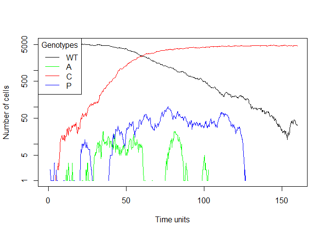

```r
## Figure 3a
afe_3_a <- allFitnessEffects(
                genotFitness =
                       create_fe(0.02, 0.04, 0.08, 0.06,
                                 0.15, 0.1, 0.06),
                frequencyDependentFitness = TRUE)
set.seed(2)
s_3_a <- oncoSimulIndiv(afe_3_a,
                     model = "McFL",
                     onlyCancer = FALSE,
                     finalTime = 160,
                     mu = 1e-4,
                     initSize = 5000,
                     keepPhylog = FALSE,
                     seed = NULL,
                     errorHitMaxTries = FALSE,
                     errorHitWallTime = FALSE)
## plot(s_3_a, show = "genotypes",
##      xlim = c(40, 200),
##      col = c("black", "green", "red", "blue"))
plot(s_3_a, show = "genotypes", type = "line",
     col = c("black", "green", "red", "blue"),
     thinData = TRUE)
```

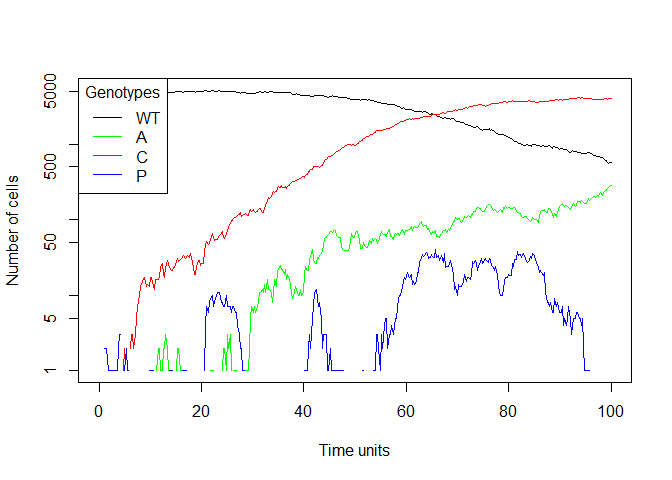

```r
## Figure 3b
afe_3_b <- allFitnessEffects(
                genotFitness =
                       create_fe(0.02, 0.04, 0.08, 0.1,
                                 0.15, 0.1, 0.05),
                frequencyDependentFitness = TRUE)
set.seed(2)
## Use a short finalTime, for speed of vignette execution
s_3_b <- oncoSimulIndiv(afe_3_b,
                     model = "McFL",
                     onlyCancer = FALSE,
                     finalTime = 100, ## 160,
                     mu = 1e-4,
                     initSize = 5000,
                     keepPhylog = FALSE,
                     seed = NULL,
                     errorHitMaxTries = FALSE,
                     errorHitWallTime = FALSE)
## plot(s_3_b, show = "genotypes",
##      col = c("black", "green", "red", "blue"))
plot(s_3_b, show = "genotypes", type = "line",
     col = c("black", "green", "red", "blue"),
     thinData = TRUE) ## thin for faster plotting
```

Of course, if we assume that the mutations leading to the different cell types are different, the results can change:

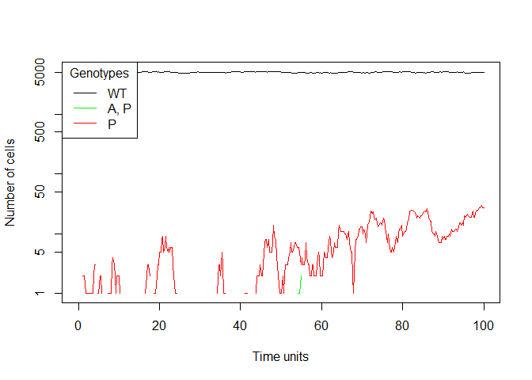

```r
## Figure 3b. Now with WT -> P; P -> A,P; P -> C,P
## For speed, we set finalTiem = 100
afe_3_b_2 <- allFitnessEffects(
                  genotFitness =
                      create_fe2(0.02, 0.04, 0.08, 0.1,
                                 0.15, 0.1, 0.05),
                  frequencyDependentFitness = TRUE,
                  frequencyType = "rel")
set.seed(2)
s_3_b_2 <- oncoSimulIndiv(afe_3_b_2,
                   model = "McFL",
                   onlyCancer = FALSE,
                   finalTime = 100, ## 300
                   mu = 1e-4,
                   initSize = 5000,
                   keepPhylog = FALSE,
                   seed = NULL,
                   errorHitMaxTries = FALSE,
                   errorHitWallTime = FALSE)
plot(s_3_b_2, show = "genotypes", type = "line",
     col = c("black", "green", "red", "blue"),
     thinData = TRUE)
```

(Examples for the remaining Figures 2 and 3 are provided, using also `oncoSimulPop`, in file ‘inst/miscell/hurlbut-ex.R’)